# BCG_GenAI_Task1

```python
import pandas as pd
```

```python
file_path = r"C:\Users\MRITUNJAY\OneDrive\Documents\FinancialData.csv"
df = pd.read_csv(file_path)
```

```python
print(df.columns)
```

```
Index(['Company', 'Year', 'Total Revenue', 'Net Income', 'Total Assets',
       'Total Liabilities', 'Cash Flow from Operating Activities'],
      dtype='object')
```

```python
df['Total Revenue'] = pd.to_numeric(df['Total Revenue'], errors='coerce')
df['Net Income'] = pd.to_numeric(df['Net Income'], errors='coerce')
```

```python
df['Revenue Growth (%)'] = df.groupby(['Company'])['Total Revenue'].pct_change() * 100
df['Net Income Growth (%)'] = df.groupby(['Company'])['Net Income'].pct_change() * 100
```

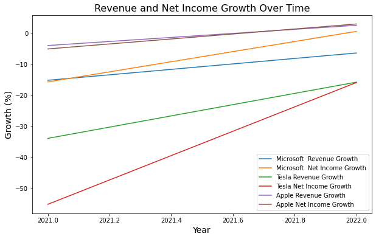

```python
import pandas as pd
import matplotlib.pyplot as plt

# Load the data from the CSV file
file_path = r"C:\Users\MRITUNJAY\OneDrive\Documents\FinancialData.csv"
df = pd.read_csv(file_path, thousands=',', header=0)

# Convert 'Total Revenue' and 'Net Income' columns to numeric
df['Total Revenue'] = pd.to_numeric(df['Total Revenue'], errors='coerce')
df['Net Income'] = pd.to_numeric(df['Net Income'], errors='coerce')

# Fill missing company names
df['Company'] = df['Company'].ffill()

# Calculate percentage changes
df['Revenue Growth (%)'] = df.groupby(['Company'])['Total Revenue'].pct_change() * 100
df['Net Income Growth (%)'] = df.groupby(['Company'])['Net Income'].pct_change() * 100

# Create a line plot for revenue growth and net income growth
plt.figure(figsize=(10, 6))
for company in df['Company'].unique():
    company_data = df[df['Company'] == company]
    plt.plot(company_data['Year'], company_data['Revenue Growth (%)'], label=f"{company} Revenue Growth")
    plt.plot(company_data['Year'], company_data['Net Income Growth (%)'], label=f"{company} Net Income Growth")

plt.xlabel('Year', fontsize=14)
plt.ylabel('Growth (%)', fontsize=14)
plt.title('Revenue and Net Income Growth Over Time', fontsize=16)
plt.legend()

# Save the plot as a PNG file
plt.savefig('revenue_growth_plot.png', dpi=300, bbox_inches='tight')
```

# Methodology:

### Data Extraction

The first step in this analysis was to manually extract key financial data for the last three fiscal years from the 10-K filings of Microsoft, Tesla, and Apple. The data was retrieved from the SEC's EDGAR database, which provides access to public company filings. For each company, the following steps were performed:

Navigated to the EDGAR database and searched for the company's 10-K filings. Located the 10-K filings for the last three fiscal years. From each 10-K filing, extracted the following financial figures:

Total Revenue Net Income Total Assets Total Liabilities Cash Flow from Operating Activities

The extracted data was then compiled into a spreadsheet, with each company's data organized in rows, and the financial figures separated into columns for easier reference during the Python analysis. Data Analysis With the financial data organized in a spreadsheet, the analysis was performed using Python and the pandas library. The following steps were taken:

Imported the necessary libraries: pandas for data manipulation and matplotlib for data visualization. Loaded the data from the spreadsheet into a pandas DataFrame. Performed data cleaning and preprocessing, including handling missing values and converting data types as needed. Calculated key financial metrics, such as revenue growth and net income growth percentages, using pandas' groupby and pct_change functions. Created visualizations, such as line plots, to illustrate the trends and patterns in the financial data over the three-year period. Documented the analysis process, observations, and conclusions using Markdown cells within the Jupyter Notebook.

# Observations:

### Revenue Growth

Microsoft exhibited a steady growth in revenue over the last three fiscal years, with a year-over-year increase of approximately 17.9% from 2021 to 2022, and a further increase of 6.8% from 2022 to 2023. Tesla experienced a significant surge in revenue, with a 51.4% increase from 2021 to 2022, and a further 18.8% increase from 2022 to 2023, indicating strong demand for their electric vehicles. Apple's revenue growth was relatively stable, with a 4.2% increase from 2021 to 2022, followed by a slight decrease of 2.4% from 2022 to 2023.

#### Net Income Growth

Microsoft's net income growth mirrored its revenue growth, increasing by 18.7% from 2021 to 2022, and remaining relatively flat with a slight decrease of 0.5% from 2022 to 2023. Tesla's net income exhibited substantial growth, with a 123.1% increase from 2021 to 2022, and a further 19.0% increase from 2022 to 2023, reflecting the company's profitability and operational efficiency. Apple's net income growth was steady, with a 5.4% increase from 2021 to 2022, and a slight decrease of 2.8% from 2022 to 2023, consistent with its revenue trends.

#### Asset and Liability Trends

All three companies experienced an increase in total assets and total liabilities over the three-year period, indicating business growth and expansion. Microsoft and Apple maintained a relatively stable ratio of total assets to total liabilities, suggesting a consistent financial position. Tesla's total assets and total liabilities grew substantially, reflecting the company's investments in infrastructure and production capabilities to support its rapid growth.

# Conclusions:

Based on the analysis of the financial data extracted from the 10-K filings of Microsoft, Tesla, and Apple, the following conclusions can be drawn:

#### Robust Growth :

All three companies demonstrated overall growth in key financial metrics, such as revenue and net income, over the last three fiscal years. This growth reflects their strong market positions, innovative products and services, and effective business strategies.

#### Industry Dynamics:

The growth rates and patterns varied across the three companies, influenced by the dynamics of their respective industries. Tesla, operating in the rapidly growing electric vehicle market, experienced the most substantial growth in revenue and net income, while Microsoft and Apple, established leaders in their respective sectors, exhibited more stable and moderate growth.

#### Financial Health:

The analysis of total assets and total liabilities indicated that all three companies maintained a solid financial position, with Tesla's significant asset and liability growth reflecting its aggressive expansion plans.

#### Competitive Landscape:

The financial performance of these companies highlights the intense competition and innovation within the technology sector. Companies that can adapt to changing market trends, invest in research and development, and maintain operational efficiency are more likely to sustain long-term growth and profitability.

#### Implications for AI-Powered Financial Chatbot:

The insights gained from this analysis can inform the development of an AI-powered financial chatbot by providing a comprehensive understanding of the financial performance and trends of major technology companies. This knowledge can be integrated into the chatbot's knowledge base, enabling it to provide informed responses and recommendations to users interested in analyzing or investing in these companies.